# Lab 5: Network generation

This lab we will work with the package `Basingstoke`, which is still not released on CRAN.

```r
install.packages('devtools')
library(devtools)
install_github('quicklizard99/Basingstoke')
```

Now let’s load the rest of the libraries we need:

```r
library(Basingstoke)
library(igraph)
library(bipartite)
library(RColorBrewer)
library(vegan)
# library(cheddar)
library(gtools)
library(tidyverse)
library(reshape2)

# We will need this function later. It is based on the code from lab 1.
plot_web_trophic <- function(g){
  basal <- which(igraph::degree(g, mode = 'in') == 0) # Basal species do not have ingoing links
  top <- which(igraph::degree(g, mode = 'out') == 0) # Top species do not have outgoing links
  interm <- V(g)[which(!V(g) %in% c(basal,top))] # Intermediate are all the rest

  V(g)$troph_pos <- rep(0,length(V(g)))
  V(g)$troph_pos[which(V(g)$name %in% basal)] <- 1
  V(g)$troph_pos[which(V(g)$name %in% top)] <- 3
  V(g)$troph_pos[which(V(g)$name %in% interm)] <- 2
  # create a matrix forthe layout coordinates.
  coords <- matrix(nrow=length(V(g)), ncol=2) #
  # The x positions are randomly selected
  coords[,1] <- runif(length(V(g)))
  # The y positions are the trophoc positions
  coords[,2] <- V(g)$troph_pos
  par(mar=c(0,0,0,0))
  plot(g,layout=coords,
              vertex.color=V(g)$troph_pos,
              vertex.label=NA,
              vertex.size=8,
              edge.color='black',
              edge.arrow.size=.3,
              edge.width=.5)
}
```

# 1. Network generation

Generating synthetic networks is the process of filling an adjaceny matirx according to a given set of rules. We will examine 3 models applied to food webs and which create unweighted food webs.

*A technical note: if you are into studying food webs, then exploring the packages `cheddar` and `Basingstoke` may prove very useful!*

## 1.1 Random model

The most straightforward way to generate a network is the **random model** in which interactions are filled randomly to obtain a network with a given connectance. “Any link among $S$ species occurs with the same probability ($P$) equal to $C$” [1]. First let’s do that with `Basingstoke` just to see how this package works.

```r
# Create 1 web with S species and a density of C
S <- 20 # Number of species
C <- 0.1 # Connectance (density)
web <- RandomLinks(1,S,C)
# Results is a list of "edge list" objects.
web <- web[[1]]
# Plot the web
g <- igraph::graph.data.frame(web)
graph.density(g)
```

```
## [1] 0.1052632
```

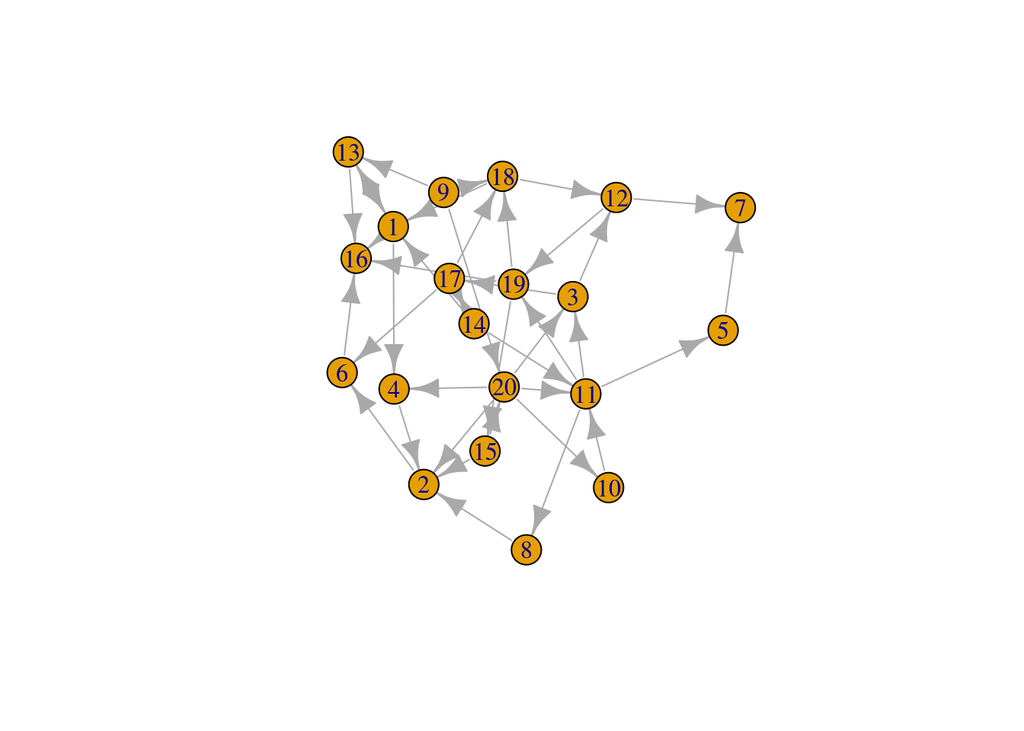

```r
plot(g)
```

```r
# Now transform the edge-list to an adjacency matrix.
A <- igraph::get.adjacency(g, sparse = F)
A[mixedsort(rownames(A)),mixedsort(colnames(A))][1:5,1:5] # mixedsort comes from library gtools
```

```
##   1 2 3 4 5
## 1 0 0 0 1 0
## 2 0 0 0 0 0
## 3 0 0 0 0 0
## 4 0 1 0 0 0
## 5 0 0 0 0 0
```

Now let’s try to program that one ourselves. We can use a command that randomly generates 0’s or 1’s with a given probability (following the definition “…the same probability ($P$) equal to $C$…” )

```r
web <- matrix(data = rbinom(S*S,1,C),nrow = S, ncol = S) # rbinom here generates either 0 or 1 with a probability of success for 1 equals C.
g <- igraph::graph.adjacency(web)
graph.density(g)
```

```
## [1] 0.1052632
```

But the `basingstike` package is usefule to generate webs.

We can take advantage of the `basingstoke` package to generate multiple webs and for plotting nicely.

```r
webs <- CommunityFactory(S=S, n=1, generator=RandomLinks, C=C) # use this function to generate an object of class "community"
class(webs) # This is a list
```

```
## [1] "CommunityCollection" "list"
```

```r
# The community class has these features
names(webs$`Artificial community 1`)
```

```
## [1] "nodes"         "properties"    "trophic.links"
```

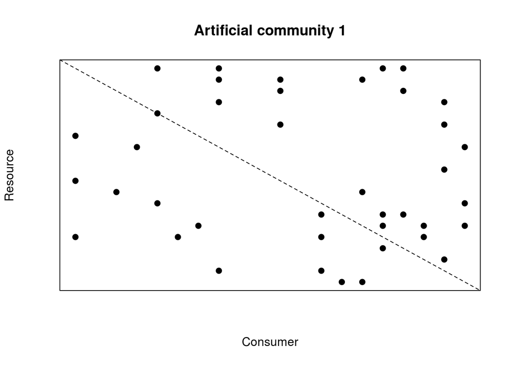

```r
# Now plot the matrix
PlotPredationMatrix(webs[[1]])
```

> 1. What essential features of food webs does the random algorithm miss?

## 1.2 Cascade model

In the cascade model, each species is assigned “a random value drawn uniformly from the interval [0,1] and each species has probability $P=2CS/(S-1)=2LS/(S-1)$ of consuming only species with values less than its own.” [1] Let’s try that algorithm while learning a bit more on the packages.

```r
web <- CascadeModelLinks(1,S,C)
# Results is a list of "edge list" objects.
web <- web[[1]]
# Plot the web
g <- igraph::graph.data.frame(web)
graph.density(g)
```

```
## [1] 0.1052632
```

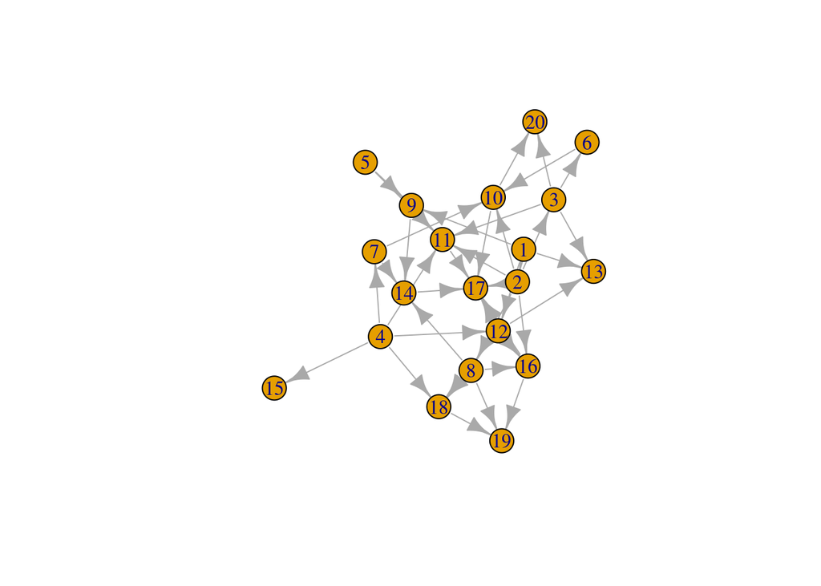

```r
plot(g)
```

```r
# Now transform the edge-list to an adjacency matrix.
A <- igraph::get.adjacency(g, sparse = F)
#A[mixedsort(rownames(A)),mixedsort(colnames(A))] # mixedsort comes from library gtools
```

We can also program that ourselves.

```r
web <- matrix(0, ncol=S, nrow=S)
num_links_allowed <- S*(S-1)/2
length(web[upper.tri(web)])==num_links_allowed
```

```
## [1] TRUE
```

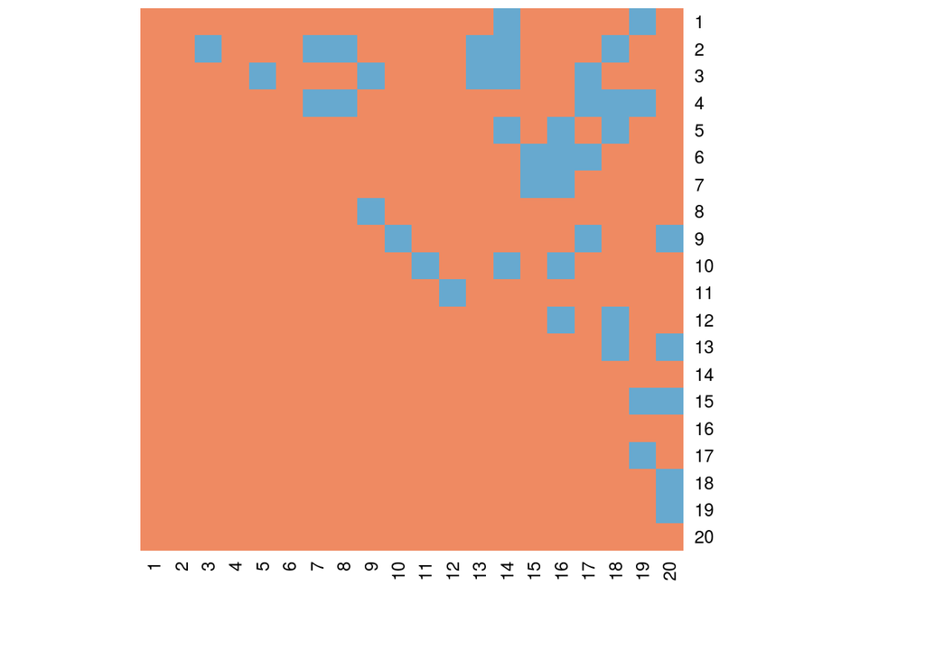

```r
web[upper.tri(web)] <- 2*C*S/(S - 1) > runif(num_links_allowed)
heatmap(web, Rowv = NA, Colv = NA, symm = F, scale = 'none', revC = T, col=brewer.pal(2,"RdBu"))
```

We can take advantage of the `basingstoke` package to generate multiple webs and for plotting nicely.

```r
webs <- CommunityFactory(S=S, n=1, generator=CascadeModelLinks, C=C) # use this function to generate an object of class "community"
class(webs) # This is a list
```

```
## [1] "CommunityCollection" "list"
```

```r
# The community class has these features
names(webs$`Artificial community 1`)
```

```
## [1] "nodes"         "properties"    "trophic.links"
```

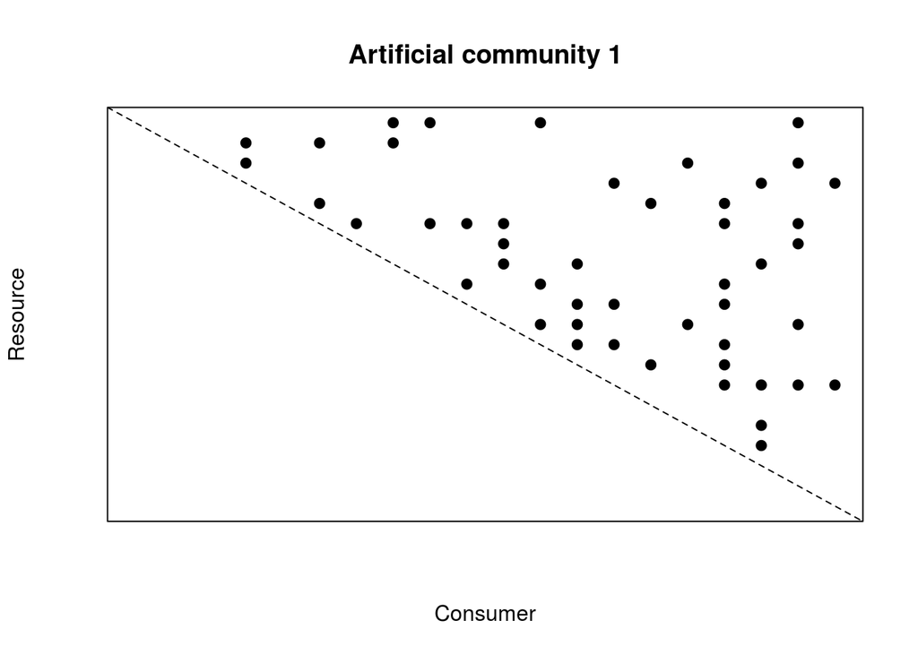

```r
# Now plot the matrix
PlotPredationMatrix(webs[[1]])
```

In fact the `CommunityFactory` function is very very convenient. It can generate multiple communities, with additional constraints. For example:

```r
# Generate 4 communities with 3 basal species
webs <- CommunityFactory(S=S, n=4, C=C, generator=CascadeModelLinks,
                         accept=function(z) sum(IsBasalNode(z))==3)
# All have 3 basal species
sapply(webs, function(z) length(BasalNodes(z)))
```

```
## Artificial community 1 Artificial community 2 Artificial community 3
##                      3                      3                      3
## Artificial community 4
##                      3
```

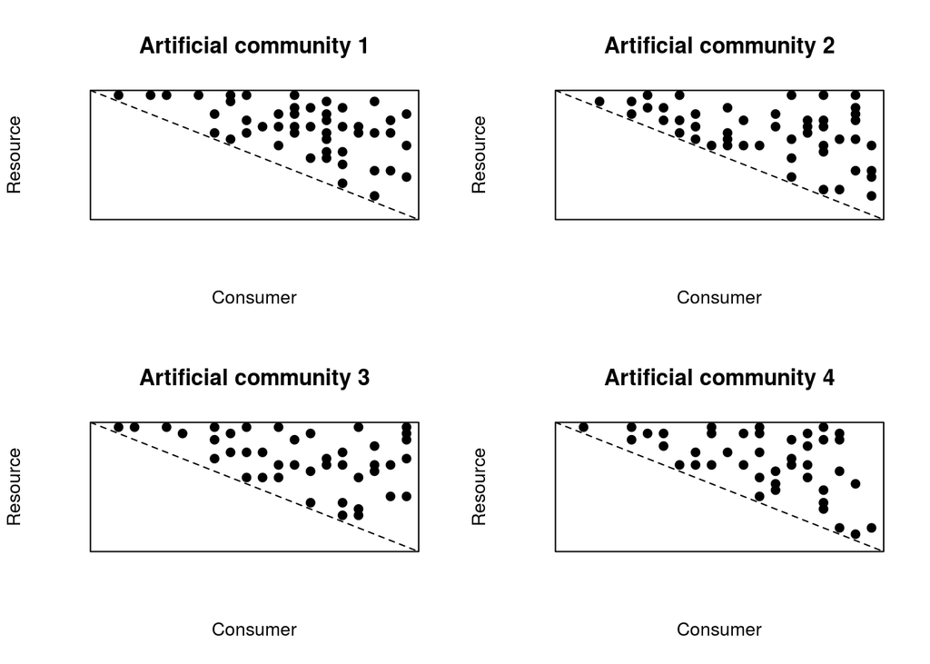

```r
par(mfrow=c(2,2))
for (i in 1:4){PlotPredationMatrix(webs[[i]])}
```

Sometimes it is convenient to work with igraph. Here is a way to move from a `community` object in `basingstoke` to igraph. From there it is also easy to obtain an adjacency matrix as w ehave seen in our previous labs about moving between data structures.

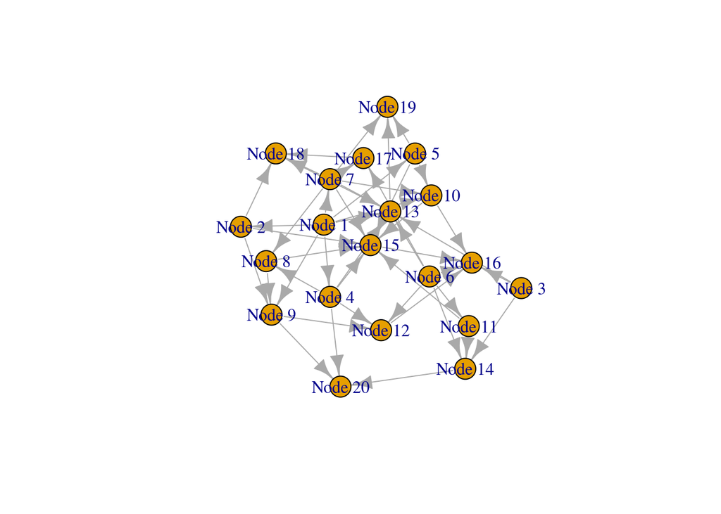

```r
g <- graph.data.frame(webs[[1]]$trophic.links, vertices = webs[[1]]$nodes)
plot(g)
```

## 1.3 Niche model

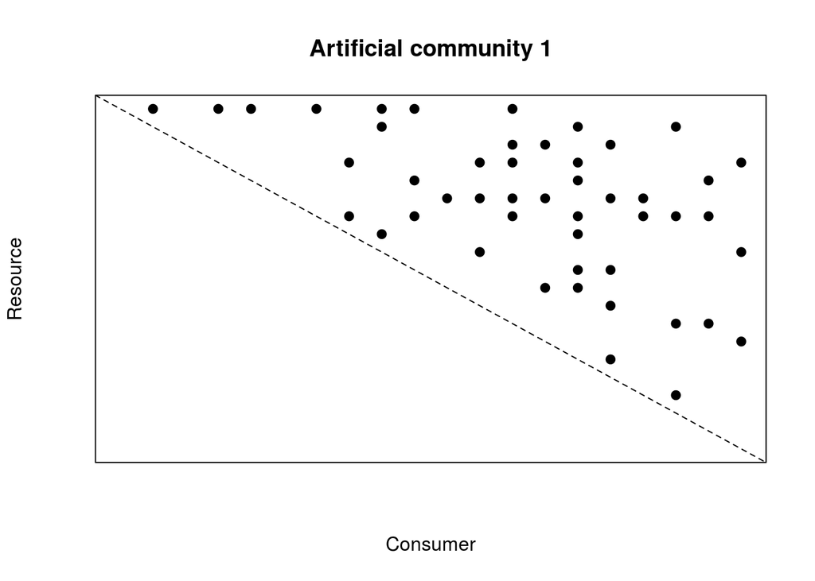

```r
web <- NicheModelLinks(1,S,C)[[1]]
PlotPredationMatrix(webs[[1]])
```

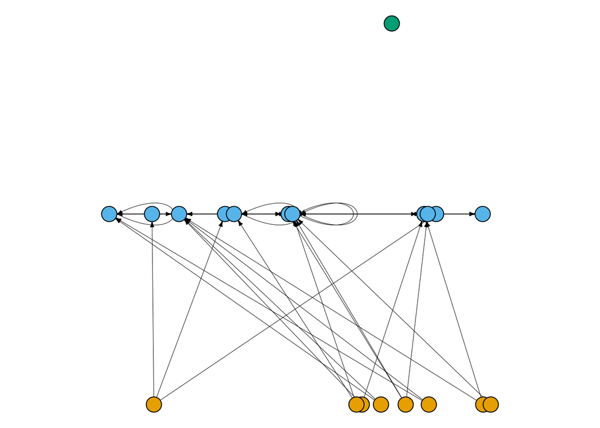

```r
# Can also plot with igraph
web <- as.data.frame(web)
web <- with(web, web[order(resource,consumer),])
nodes <- data.frame(name=1:S)
g <- graph.data.frame(web, vertices = nodes)
plot_web_trophic(g)
```

Or we can program that niche model ourselves. For this I followed the caption in Fig. 1 of Williams and Martinez (2000), but I took the beta value to be equal (S-1)/2SC-1 from equation 10 in the Supp Info of Allesina et al. (Science, 2008). I also got some code from the function `NicheModelLinks` for the last step determining the consumers.

```r
S=100
C=0.15
n_i <- sort(runif(S, 0, 1)) # Positions on a niche axis between 0 and 1.
mean(n_i) # The expected mean of n_i should be 0.5
```

```
## [1] 0.4982866
```

```r
beta <- (S-1)/(2*S*C)-1
r_i <- rbeta(S, 1, beta) # Draw r_i values from a beta distribution with alpha=1.
mean(r_i) # The expected mean of r_i should be 2*C
```

```
## [1] 0.3406725
```

```r
r_i <- r_i*n_i # The final size of r_i is obtained by multiplying by n_i to obtain C
mean(r_i)
```

```
## [1] 0.1710067
```

```r
r_i[1] <- 0 # The species with the smallest n_i (which is the first in the vector) has r_i = 0 to have at least one basal species

# uniformly draw the centre of the range (c_i) from [r_i/2, n_i]
# c_i <- t(runif(S, min=r_i/2, max=n_i)) # This would not work because the basal species would be always disconnected
c_i <- matrix(runif(S, min = r_i/2, max = pmin(n_i, 1 - r_i/2)), ncol = S)

# A species i consumes whatever is in the range [c_i - r_i/2, c_i + r_i/2]
consume <- outer(n_i, c_i - r_i/2, ">=") & outer(n_i, c_i + r_i/2, "<=")
sum(consume)/S^2 # Do we recover C?
```

```
## [1] 0.1754
```

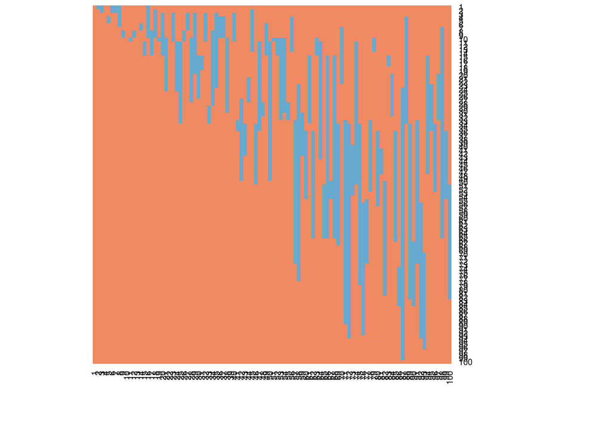

```r
# Make the matrix
web <- matrix(0,S,S)
web[which(consume==T)] <- 1
# Plot
heatmap(web, Rowv = NA, Colv = NA, symm = F, scale = 'none', revC = T, col=brewer.pal(2,"RdBu"))
```

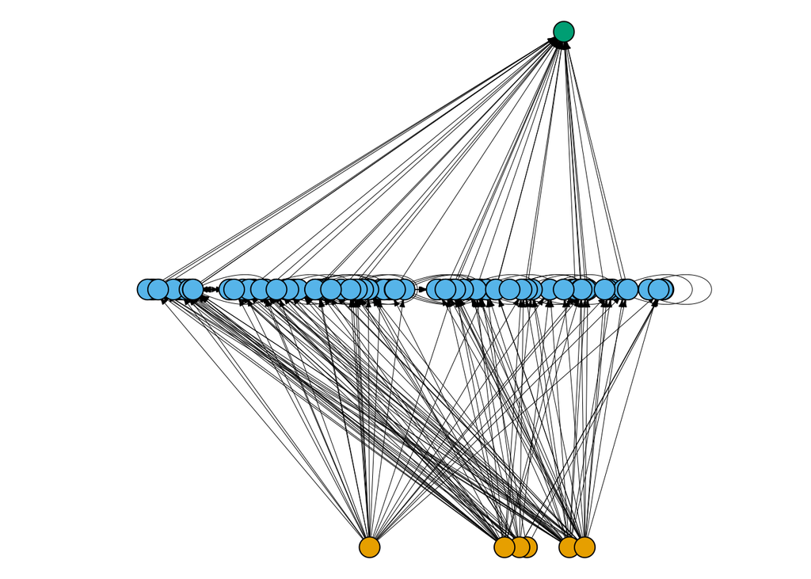

```r
# Can also plot with igraph
colnames(web) <- rownames(web) <- 1:S
g <- graph.adjacency(web)
plot_web_trophic(g)
```

## 1.4 The group model

In the group model, species are assigned to groups, each with its own per-group probability of a link. In addition, there are probabilities to connect between groups. The following code is from Stefano Allesina.

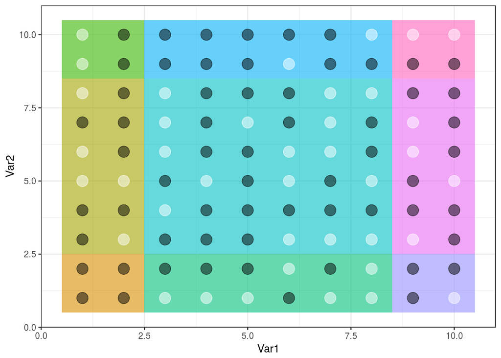

```r
generate_group_model <- function(groups, P, S){
    ## Pij is the probability of connecting a member of group i with a member of group j
    ## S is the total number of species
    ## groups is a vector of group memberships
    M <- matrix(rbinom(S^2, size = 1, prob = P[groups, groups]), S, S)
    ## sort elements in M by groups
    M <- M[order(groups), order(groups)]
    return(M)
}

S <- 10
groups <- rbinom(S, size = 2, 0.5)
m <- max(groups)
P <- matrix(runif((m + 1)^2), m + 1, m + 1)

M <- generate_group_model(groups, P, S)
groups <- groups[order(groups)] + 1
## Make a plot by groups
Mplot <- tbl_df(melt(t(M))) %>% mutate(Var2 = S - Var2 + 1, group1 = groups[Var1], group2 = groups[Var2], tag = (group1-1) * (m + 1) + group2)

Mplot %>% ggplot(aes(x = Var1, y = Var2, fill = as.character(tag))) + geom_tile(alpha = 0.6) + theme_bw() + geom_point(size = 5, alpha = 0.5, aes(fill = as.factor(value), colour=  as.factor(value))) + scale_colour_manual(values = c("white", "black")) + theme(legend.position = "none")
```

# 2. Other resources

These models have been in the literature for quite a while, and so many people have cidifed them. For example, you can find excellent code by [Owen Petchey](http://www.ieu.uzh.ch/en/staff/member/petchey_owen.html) [here](https://github.com/opetchey/ttl-resources/blob/master/food_web/FoodWebFunctions.r). This code has more elaborate functions for food web properties. Here is his code for the cascade model:

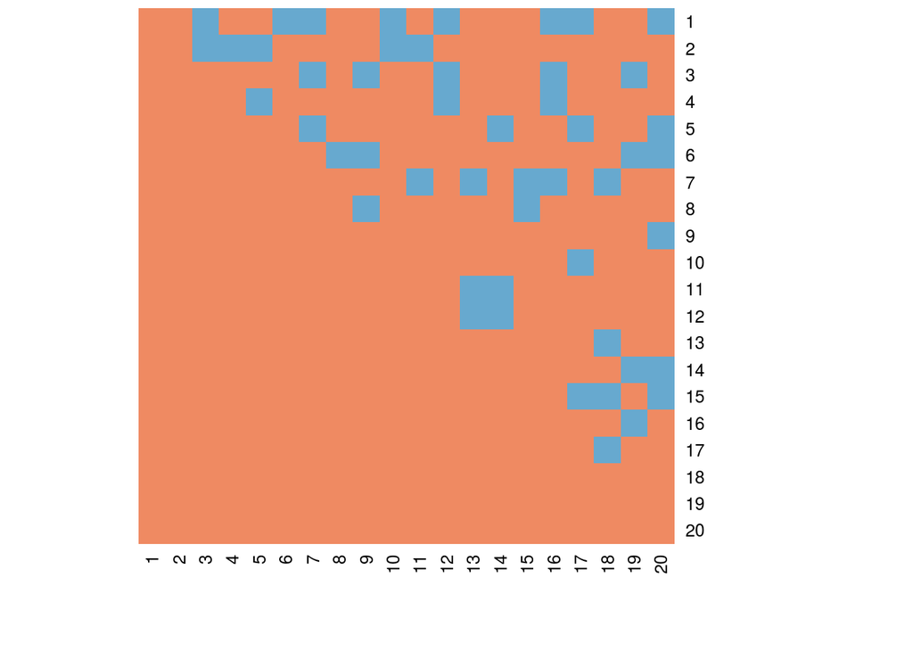

```r
S=20
L=50
C=L/S^2
web <- matrix(0, S, S)
web[upper.tri(web)] <- c(rep(1, L), rep(0, (S^2-S)/2-L))[order(runif((S^2-S)/2))]
dimnames(web) <- list(1:length(web[,1]), 1:length(web[,1]))
heatmap(web, Rowv = NA, Colv = NA, symm = F, scale = 'none', revC = T, col=brewer.pal(2,"RdBu"))
```

# 3. Comparing networks

# 3.1 Using network properties

Let’s put that in practice. We will take an empirical food web, and try to capture some of its properties using generated food webs. Based on a set of network properties we can then compare and see which generative model captures best the empirical properties. **Note that this is only an illustration!! I randomly selected some properties, but you can choose others.**

This function implements some properties.

```r
calculateProperties <- function(g){
  A <- as_adjacency_matrix(g, type = 'both', sparse = F)
  L <- sum(A!=0)
  S <- nrow(A)
  C <- L/S^2
  #C <- graph.density(g) # Also possible
  GenSD <- sd(1/(L/S)*rowSums(A)) # Generality of species i
  VulSD <- sd(1/(L/S)*colSums(A)) # Vulnerability of species i

  Top <- sum(rowSums(A)==0)/vcount(g) # Top species do not have outgoing links
  Bas <- sum(colSums(A)==0)/vcount(g) # Basal species do not have ingoing links
  Int <- 1-(Top+Bas) # Intermediate are all the rest

  basal_species <- which(colSums(A) == 0)
  chain_length_mean <- mean(distances(g, v=basal_species))
  chain_length_sd <- sd(distances(g, v=basal_species))
  Cannib <- sum(diag(A)>0)/S

  return(data.frame(L=L,C=C,GenSD=GenSD,VulSD=VulSD,Top=Top,Bas=Bas,Int=Int,ChnLg=chain_length_mean,ChnSd=chain_length_sd,Cannib=Cannib))
}
```

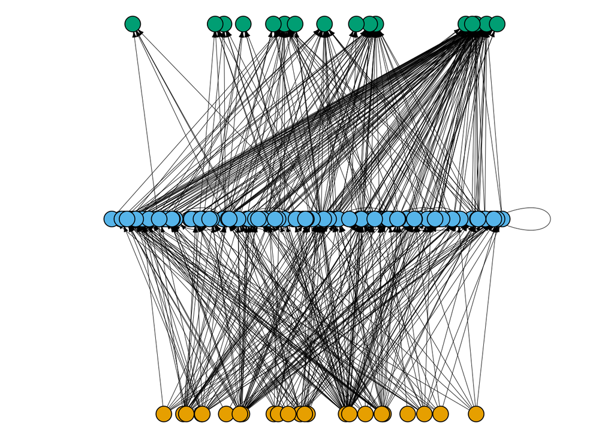

```r
otago_nodes <- read.csv('https://raw.githubusercontent.com/pascualgroup/Networks_course/master/Network_data/Otago_Data_Nodes.csv?token=ADd8OEIltgIeGLGKTneIrBNkopbsObJXks5a4hKrwA%3D%3D')
otago_links <- read.csv('https://raw.githubusercontent.com/pascualgroup/Networks_course/master/Network_data/Otago_Data_Links.csv?token=ADd8OAomGiQRFtpaN-AFt2ePFIEa8ZPQks5a4hPRwA%3D%3D')
otago_web <- graph.data.frame(otago_links, vertices = otago_nodes, directed = T)

plot_web_trophic(otago_web)
```

```r
empirical <- calculateProperties(otago_web)
```

Now generate N networks with the cascade and niche models and calculate their network properties.

```r
S=vcount(otago_web)
C=graph.density(otago_web)
N <- 100

## Random model
webs <- NULL
for (i in 1:N){
  webs[[i]] <- matrix(data = rbinom(S*S,1,C),nrow = S, ncol = S)
}
graphs_list <- NULL
for (i in 1:N){
  graphs_list[[i]] <- graph.adjacency(webs[[i]], mode = 'directed')
}
generated_properties_random <- lapply(graphs_list, calculateProperties)
generated_properties_random <- do.call(rbind, generated_properties_random)
generated_properties_random <- reshape2::melt(generated_properties_random)


## Cascade model
webs <- CommunityFactory(S=S, n=N, generator=CascadeModelLinks, C=C) # use this function to generate an object of class "community"
graphs_list <- NULL
for (i in 1:N){
  graphs_list[[i]] <- graph.data.frame(webs[[i]]$trophic.links, directed = T, vertices = webs[[i]]$nodes)
}
generated_properties_cascade <- lapply(graphs_list, calculateProperties)
generated_properties_cascade <- do.call(rbind, generated_properties_cascade)
generated_properties_cascade <- reshape2::melt(generated_properties_cascade)

## Niche model
webs <- CommunityFactory(S=S, n=N, generator=NicheModelLinks, C=C) # use this function to generate an object of class "community"
graphs_list <- NULL
for (i in 1:N){
  graphs_list[[i]] <- graph.data.frame(webs[[i]]$trophic.links, directed = T, vertices = webs[[i]]$nodes)
}
generated_properties_niche <- lapply(graphs_list, calculateProperties)
generated_properties_niche <- do.call(rbind, generated_properties_niche)
generated_properties_niche <- reshape2::melt(generated_properties_niche)
```

Now let’s see how they compare to each other and to the empirical data.

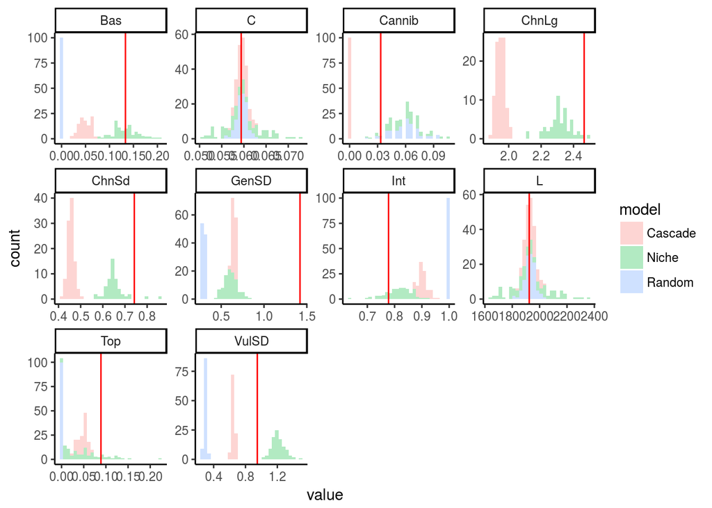

```r
# Data frame from the empirical value, to plot vertical lines on the histograms
intercept_data <- as.data.frame(t(empirical)[,1])
names(intercept_data)[1] <- 'intercept'
intercept_data$variable <- rownames(intercept_data)

# Plot
generated_properties_random$model <- 'Random'
generated_properties_cascade$model <- 'Cascade'
generated_properties_niche$model <- 'Niche'
d <- rbind(generated_properties_random,generated_properties_cascade,generated_properties_niche)
ggplot(d, aes(value, fill=model))+geom_histogram(alpha=0.3)+facet_wrap(~variable, scales='free')+geom_vline(data = intercept_data, aes(xintercept = intercept), color='red')+theme_classic()
```

# 3.2 Using likelihood

### 3.2.1 A visualization of model maximum likelihoods

Allesina, Alonso & Pascual (Science, 2008) derived the likelihood functions (and their m.l.e values) for several generative models. For example, the log-likelihood of the random model is $L*log(p)+(S^2-L)*log(1-p)$ and it is maximized when $p=L/S^2$.

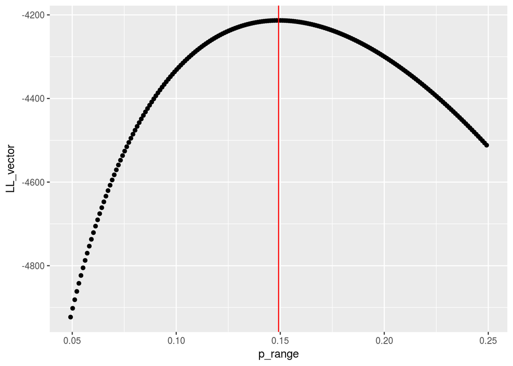

```r
S=100
C=0.15
web <- matrix(data = rbinom(S*S,1,C),nrow = S, ncol = S)
L=sum(web>0)
p_max=L/S^2
LL_vector=NULL # Store results of log-likelihood
p_range <- seq(p_max-0.1,p_max+0.1,0.001)
for (p in p_range){
  LL <- L*log(p)+(S^2-L)*log(1-p)
  LL_vector <- c(LL_vector, LL)
}
qplot(x=p_range, y=LL_vector)+geom_vline(xintercept = p_max, color='red')
```

```r
p_range[which.max(LL_vector)] # Connectance corresponding to the maximum log-likelihood
```

```
## [1] 0.1492
```

The log-likelihood function of the cascade model is $log(p)L+log(1-p)\cdot (S(S-1)/2-L)$ and it is maximized when $p=2CS/(S - 1)$.

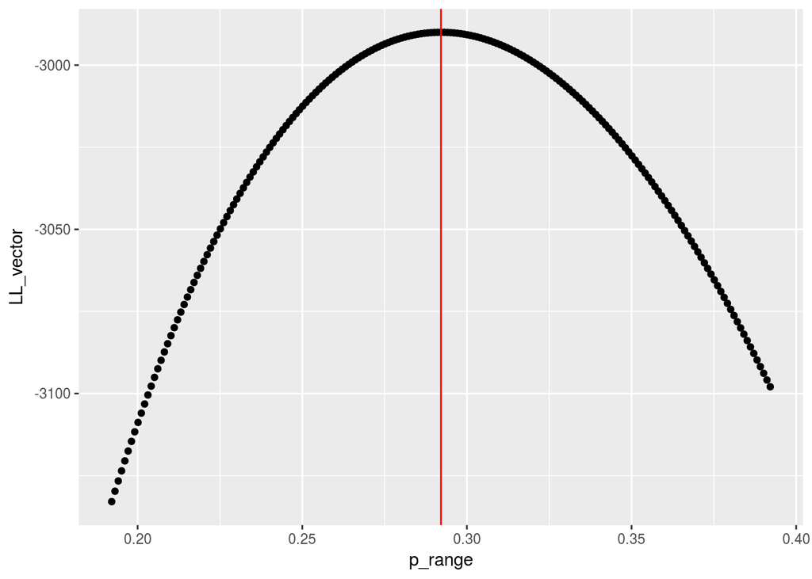

```r
# Generate a random network with the cascade model
S=100
C=0.15
web <- matrix(0, ncol=S, nrow=S)
num_links_allowed <- S*(S-1)/2
web[upper.tri(web)] <- 2*C*S/(S - 1) > runif(num_links_allowed)
L=sum(web>0) # Number of links in the generated network
C=L/S^2 # Connectance of the generatd network
p_max=2*C*S/(S - 1) # The value which maximizes the likelihood
LL_vector=NULL # Store results of log-likelihood
p_range <- seq(p_max-0.1,p_max+0.1,0.001) # A range to calculate the likelihoods
for (p in p_range){
  LL <- L*log(p)+(S*(S-1)/2-L)*log(1-p)
  LL_vector <- c(LL_vector, LL)
}
# d <- data.frame(p_range=p_range, LL_vector=LL_vector)
# d <- d %>% arrange(LL_vector, p_range)
qplot(x=p_range, y=LL_vector)+geom_vline(xintercept = p_max, color='red')
```

```r
p_range[which.max(LL_vector)]-p_max # Connectance corresponding to the maximum log-likelihood
```

```
## [1] 0
```

### 3.2.2 Comparing between models using likelihoods

The likelihood allows us to compare different models, asking the question, which of the models better fits the data? For example, if we compared the Random Model to the Modified Cascade:

```r
S <- vcount(otago_web)
L <- ecount(otago_web)

# random
p <- L/S^2
LL_random <- L*log(p)+(S^2-L)*log(1-p)

# Modified cascade
A <- as_adjacency_matrix(otago_web, sparse=F)
L1 <- sum(A[upper.tri(A)]>0)
L2 <- sum(A[lower.tri(A)]>0)+sum(diag(A))
q1 <- 2*L1/(S*(S-1))
q2 <- 2*L2/(S*(S+1))
LL_modified1 <- L1*log(q1)+(S*(S-1)/2-L1)*log(1-q1)
LL_modified2 <- L2*log(q2)+(S*(S+1)/2-L2)*log(1-q2)
LL_modified <- LL_modified1+LL_modified2
data.frame(model=c('R','M'), loglik=c(LL_random,LL_modified)) %>% arrange(desc(loglik))
```

```
##   model    loglik
## 1     M -7286.475
## 2     R -7298.607
```

### 3.2.3 Using likelihood to fit a model to network data

Note that for the Modified Cascade model I used this version of the likelihood function: $q_1^{L_1}(1-q_1)^{S(S-1)/2-L_1}\times q_2^{L_2}(1-q_2)^{S(S+1)/2-L_2}$. However, if we look at the original likelihood functions, we see that the empirical adjacency matrix $A_{ij}$ is a parameter in the likelihood functions of the Cascade, Modified Cascade and Niche models. **Therefore, if we change the order of the rows or columns of $A_{ij}$, we can obtain a different value for the likelihood function!** Purely for the sake of the example, in the code above we assumed that the line `A <- as_adjacency_matrix(otago_web, sparse=F)` gave us a matrix $A_{ij}$ which was ordered in a way that would maximize the likelihood function of the Modified Cascade model, $\prod_{i}^{S}\prod_{j>i}^{S}\lbrack q_1^{A_{ij}}(1-q_1)^{1-A_{ij}}\rbrack \prod_{i}^{S}\prod_{j=1}^{i}\lbrack q_2^{A_{ij}}(1-q_2)^{1-A_{ij}}\rbrack$. That would allow us to use the likelihood function I used. But that is not necessarily the case. To find the maximum likelihood, we should search for the optimal order of $A_{ij}$, which maximizes the likelihod.

**Our exercise now in class would be to devise a pseudo-code that maximizes the likelihood.**

# 4. Applications

Generating networks can be used to test, for example, hypotheses regarding the consequences of structure. For example, we can ask if networks generated with the niche model are more robust than those generated using an Erdos-Reyni process. One exercise would be to generate a distribution of networks of a given size and connectance using different models and test their robustness. Try to do develop that code. You can also try to test if robustness is affected by the interaction between size, connectance and the different models (i.e., if different models produce more robust networks for a give nrange of $S$ or $C$).